# Week 6: RMarkdown

Keanu Rochette-Yu Tsuen

2024-10-01

# Introduction to RMarkdown

Let’s give it a shot a *RMarkdown*!  
We will use the Penguin data to practice.

## Load the Libraries

```r
library(palmerpenguins)
library(tidyverse)
library(here)
library(kableExtra) # to make tables in RMarkdown
```

## Comments in RMarkdown

Comment structure use <&!– XXX –>, without the “&”.  
This is comment will be shown tho.

## Inspect the data

```r
glimpse(penguins)
```

```
## Rows: 344
## Columns: 8
## $ species           <fct> Adelie, Adelie, Adelie, Adelie, Adelie, Adelie, Adel…
## $ island            <fct> Torgersen, Torgersen, Torgersen, Torgersen, Torgerse…
## $ bill_length_mm    <dbl> 39.1, 39.5, 40.3, NA, 36.7, 39.3, 38.9, 39.2, 34.1, …
## $ bill_depth_mm     <dbl> 18.7, 17.4, 18.0, NA, 19.3, 20.6, 17.8, 19.6, 18.1, …
## $ flipper_length_mm <int> 181, 186, 195, NA, 193, 190, 181, 195, 193, 190, 186…
## $ body_mass_g       <int> 3750, 3800, 3250, NA, 3450, 3650, 3625, 4675, 3475, …
## $ sex               <fct> male, female, female, NA, female, male, female, male…
## $ year              <int> 2007, 2007, 2007, 2007, 2007, 2007, 2007, 2007, 2007…
```

# Figures in RMarkdown

## Make a simple plot

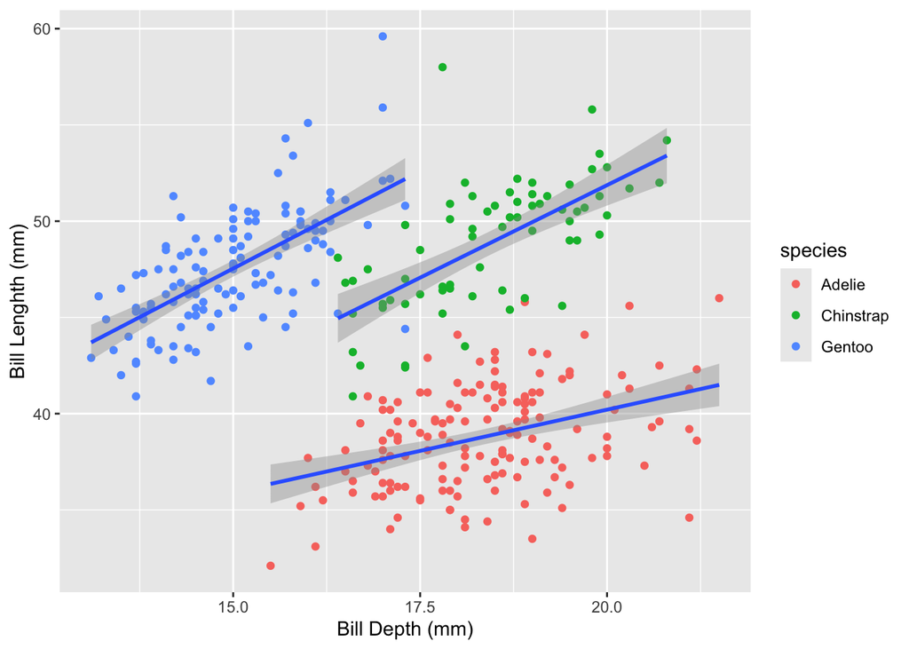

```r
ggplot(penguins,
        aes(x= bill_depth_mm, y = bill_length_mm, group = species)) +
  geom_point(aes(color = species))+
  geom_smooth(method = "lm")+
  labs(x= "Bill Depth (mm)",
       y = "Bill Lenghth (mm)")
```

## Changing the size

Specify those within the {r} of the code chunk.  
Those can also be specified in the knitr::opts_chunk section so it applies to all of the figures produced in the document.  
- out.width = “70%” (70% of the width)  
- fig.width = 3 (width 3 in)  
- fig.height = 4 (height 4 in)  
- fig.asp = 1.2 (aspect ratio of 1.2)  
- fig align = “center”

#### out.width = “70%”

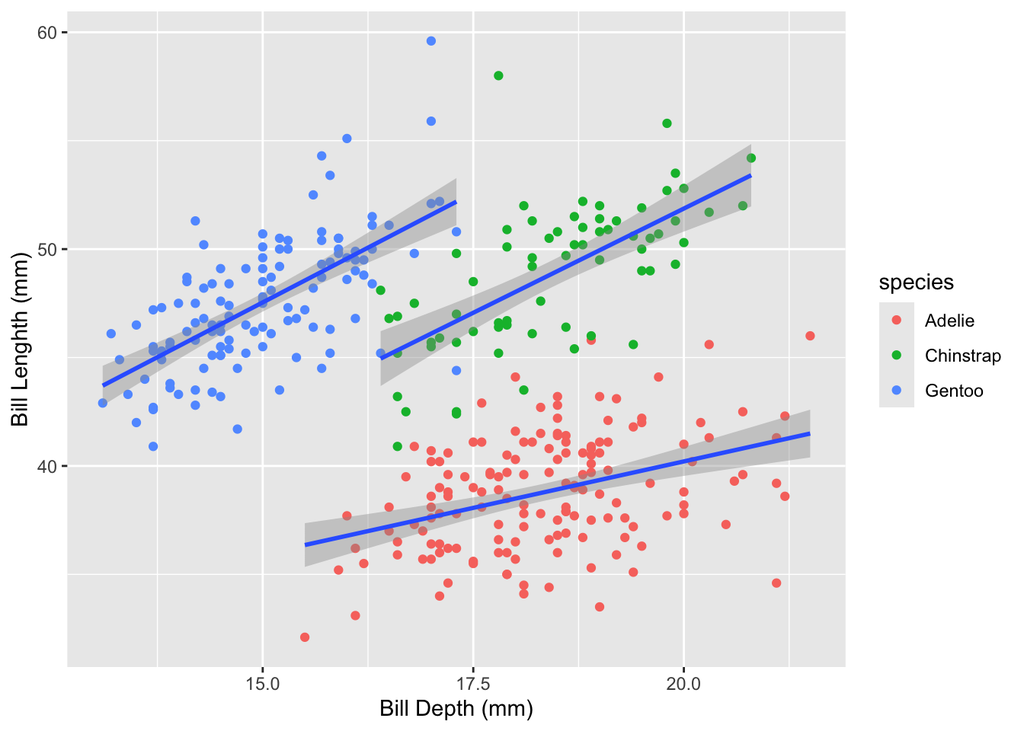

```r
ggplot(penguins,
        aes(x= bill_depth_mm, y = bill_length_mm, group = species)) +
  geom_point(aes(color = species))+
  geom_smooth(method = "lm")+
  labs(x= "Bill Depth (mm)",
       y = "Bill Lenghth (mm)")
```

#### fig.width = 4, fig.height= 3

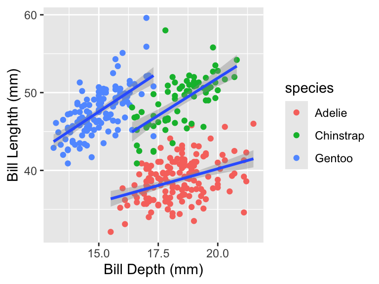

```r
ggplot(penguins,
        aes(x= bill_depth_mm, y = bill_length_mm, group = species)) +
  geom_point(aes(color = species))+
  geom_smooth(method = "lm")+
  labs(x= "Bill Depth (mm)",
       y = "Bill Lenghth (mm)")
```

#### fig.asp= 1.2

```r
ggplot(penguins,
        aes(x= bill_depth_mm, y = bill_length_mm, group = species)) +
  geom_point(aes(color = species))+
  geom_smooth(method = "lm")+
  labs(x= "Bill Depth (mm)",
       y = "Bill Lenghth (mm)")
```

[output not shown]

#### fig.asp= 1.2, fig.align= “center”

```r
ggplot(penguins,
        aes(x= bill_depth_mm, y = bill_length_mm, group = species)) +
  geom_point(aes(color = species))+
  geom_smooth(method = "lm")+
  labs(x= "Bill Depth (mm)",
       y = "Bill Lenghth (mm)")
```

[output not shown]

## Save the figures

This is an alternative to ggsave, an automated way.  
It’s important that all the code chunks are *NAMED*. {r *label*}, no spaces. You can only have *ONE figure* per R chunk.

Set the figure path within knitr::opts_chunk.  
We can’t use here() in this case unfortunately.  
–> fig.path = “../outputs/”

#### fig.path = “../outputs/”

```r
ggplot(penguins,
        aes(x= bill_depth_mm, y = bill_length_mm, group = species)) +
  geom_point(aes(color = species))+
  geom_smooth(method = "lm")+
  labs(x= "Bill Depth (mm)",
       y = "Bill Lenghth (mm)")
```

[output not shown]

```r
# this figure was indeed saved in the outputs folder
```

## Giving the figure a caption: fig.cap = “…”

```r
ggplot(penguins,
        aes(x= bill_depth_mm, y = bill_length_mm, group = species)) +
  geom_point(aes(color = species))+
  geom_smooth(method = "lm")+
  labs(x= "Bill Depth (mm)",
       y = "Bill Lenghth (mm)")
```

[output not shown]

This is a scatter plot of penguin data

## Saving the figure in a specific format: dev = ” *specific format type* ”

```r
ggplot(penguins,
        aes(x= bill_depth_mm, y = bill_length_mm, group = species)) +
  geom_point(aes(color = species))+
  geom_smooth(method = "lm")+
  labs(x= "Bill Depth (mm)",
       y = "Bill Lenghth (mm)")
```

[figure not shown]

This is a scatter plot of penguin data

```r
#Note: this figure was saved as a pdf. In the html output, it shows as a scrolling figure
```

# Tables in RMarkdown

## Manual method

You can do it by hand. It is extremely tedious and takes accuracy to code it right.

| Time | Session | Topic |
| --- | --- | --- |
| *left* | *center* | *right* |
| 01:00 | 1 | Anatomy |
| 01:50 |  | *Break* |
| 02:00 | 2 | Tables |
| 02:45 |  | *Break* |

## Tables with kable

Load the kableExtra package in the library section.

```r
penguins %>%
  group_by(species) %>%
  summarize(bill_mean = mean(bill_length_mm, na.rm = T)) %>%
  kbl() # generates a kable table
```

| species | bill_mean |
| --- | --- |
| Adelie | 38.79139 |
| Chinstrap | 48.83382 |
| Gentoo | 47.50488 |

You can also change the look of the table by adding more details and instructions

```r
penguins %>%
  group_by(species) %>%
  summarize(bill_mean = mean(bill_length_mm, na.rm = T)) %>%
  kbl() %>%
  kable_classic() %>% # table theme
  row_spec(2, bold = T, color = "white", background = "red")
```

| species | bill_mean |
| --- | --- |
| Adelie | 38.79139 |
| Chinstrap | 48.83382 |
| Gentoo | 47.50488 |

```r
# select row 2, bold text, white color and red background
```

Changing the size of the table

```r
penguins %>%
  group_by(species) %>%
  summarize(bill_mean = mean(bill_length_mm, na.rm = T)) %>%
  kbl() %>%
  kable_classic() %>% # table theme
  row_spec(2, bold = T, color = "white", background = "red") %>%
      # select row 2, bold text, white color and red background
  kable_styling(full_width = F) # gives a narrower table
```

| species | bill_mean |
| --- | --- |
| Adelie | 38.79139 |
| Chinstrap | 48.83382 |
| Gentoo | 47.50488 |

There are lot more packages that can make tables even better in RMarkdown. https://rfortherestofus.com/2019/11/how-to-make-beautiful-tables-in-r/

# Themes in RMarkdown

So many to choose from and more to download.

https://www.datadreaming.org/posts/2018-04-11-r-markdown-theme-gallery/2018-04-11-r-markdown-theme-gallery

# Output formats

Try Github Document: https://rmarkdown.rstudio.com/github_document_format.html

Each type of outputs has different arguments and are not transferable. Beware of the type chosen.